# Health and economic effects of severe weather events in the US from 1996 to 2011

Alberto Jaimes

January 2018

### Sypnosis

I explored the U.S. *NOAA*’storm database, focusing in the health, and economic impact of weather events during the 1996 - 2011 period. I found that **excessive heat** is responsible for more deaths that any other weather event; besides, **tornadoes** provoque more injuries that any other event, by far. In terms of economic impact, the **hurricanes** lead, by a lot, to more economic damage than any other event, specially in crops.

### Data Processing

#### Settings

```r
knitr::opts_chunk$set(echo = TRUE, cache = TRUE)
library(R.utils)   # function to unzip data
library(tidyverse) # useful packages for data science
library(janitor)   # clean variable names
library(lubridate) # makes easy handle dates
library(gridExtra) # help for plotting
```

#### Data downloading

```r
url_nooa <- "https://d396qusza40orc.cloudfront.net/repdata%2Fdata%2FStormData.csv.bz2"
path_compressed   <- "Storm_data.csv.bz2"
path_uncompressed <- "Storm_data.csv"
# download data if they are not in the working directory, and uncompress them
if (!file.exists(path_compressed)) {
  download.file(url = url_nooa, destfile = path_compressed)
  R.utils::bunzip2(path_compressed, destname = path_uncompressed, remove = FALSE)
}
```

#### Data loading

```r
# loading, then cleaning names
storm_raw <- readr::read_csv(path_uncompressed) %>% clean_names()
```

#### Data structure

```r
glimpse(storm_raw)
```

```
## Observations: 902,297
## Variables: 37
## $ state       <dbl> 1, 1, 1, 1, 1, 1, 1, 1, 1, 1, 1, 1, 1, 1, 1, 1, 1,...
## $ bgn_date    <chr> "4/18/1950 0:00:00", "4/18/1950 0:00:00", "2/20/19...
## $ bgn_time    <chr> "0130", "0145", "1600", "0900", "1500", "2000", "0...
## $ time_zone   <chr> "CST", "CST", "CST", "CST", "CST", "CST", "CST", "...
## $ county      <dbl> 97, 3, 57, 89, 43, 77, 9, 123, 125, 57, 43, 9, 73,...
## $ countyname  <chr> "MOBILE", "BALDWIN", "FAYETTE", "MADISON", "CULLMA...
## $ state_2     <chr> "AL", "AL", "AL", "AL", "AL", "AL", "AL", "AL", "A...
## $ evtype      <chr> "TORNADO", "TORNADO", "TORNADO", "TORNADO", "TORNA...
## $ bgn_range   <dbl> 0, 0, 0, 0, 0, 0, 0, 0, 0, 0, 0, 0, 0, 0, 0, 0, 0,...
## $ bgn_azi     <chr> NA, NA, NA, NA, NA, NA, NA, NA, NA, NA, NA, NA, NA...
## $ bgn_locati  <chr> NA, NA, NA, NA, NA, NA, NA, NA, NA, NA, NA, NA, NA...
## $ end_date    <chr> NA, NA, NA, NA, NA, NA, NA, NA, NA, NA, NA, NA, NA...
## $ end_time    <chr> NA, NA, NA, NA, NA, NA, NA, NA, NA, NA, NA, NA, NA...
```

[output cut: 24 more lines]

#### Selecting useful variables

The variables with information of the effect are **bgn_date**, the year the event started, **evtype**, the event type, **injuries**, the amount of injured people, **fatalities**, the toll caused by the weather event, **propdmg**, property damage rounded up to three significative digits, **propdmgexp**, magnitude of the property damage, **cropdmg**, crop damage up to three signifivative digits, and **cropdmgexp**, magnitude of the crop damage.

```r
# select useful variables, extract year of the events, and transform character variables
storm_all <- storm_raw %>%
  select(bgn_date, evtype, injuries, fatalities, propdmg:cropdmgexp) %>%
  mutate(year = year(mdy_hms(bgn_date)), evtype = str_to_title(evtype),
         propdmgexp = str_to_lower(propdmgexp), cropdmgexp = str_to_lower(cropdmgexp)) %>%
  select(-bgn_date)
```

#### Filter observations

The yearly numbers of events is shown in the next plot.

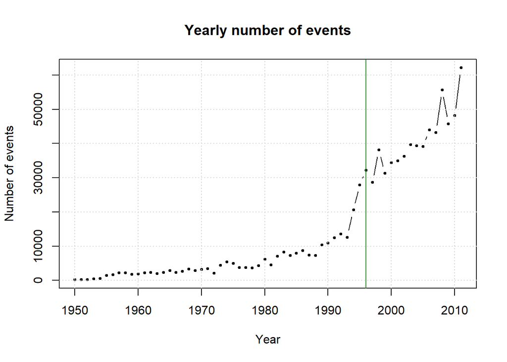

```r
storm_all %>% count(year) %>% plot(type = "b", pch = 19, cex = .5, ann = FALSE)
title(xlab = "Year", ylab = "Number of events", main = "Yearly number of events")
abline(v = 1996, col = "forestgreen")
grid()
```

The earlier years have fewer events recorded, likely due to a lack of recording; I will do the analysis with events since 1996, and with values bigger than zero.

```r
storm_recent <- filter(storm_all, year >= 1996,
                       propdmg > 0 | cropdmg > 0 | injuries > 0 | fatalities > 0)
```

#### Event Type Preprocessing

The next table displays the top ten weather events in injuries.

```r
storm_recent %>%
  count(evtype, wt = injuries, sort = T) %>% rename(events = n) %>%
  head(10) %>% knitr::kable()
```

[output not shown]

*Ttsm Wind* and *Thunderstorm Wind* correspond to the same event type; nevertheles, their records are splited in two different *evtype*. This behaviour is repeated in other cases, e. g. *Hurricane* and *Hurricane/Typhoon*. In this step I gather the several forms of each **evtype**.

```r
patterns <- c("hurrican.+" = "hurricane", "typhoon" = "hurricane", "wind " = "winds ",
              "heavy rain.+" = "heavy rain", "rains " = "rain", "hvy" = "heavy",
              "tstm" = "thunderstorm", "thundertorm" = "thunderstorm",
              "thunderstormw" = "thunderstorm", "thunderstorms" = "thunderstorm",
              "thundeerstorm" = "thunderstorm", "thunderestorm" = "thunderstorm",
              "\\s+" = " ", "\\." = "", "(|)" = "", "^\\s+" = "", "\\s+$" = "")
# lowercase, them replace patterns, finally coerse evtype to title
storm_final <- storm_recent %>%
  mutate(evtype = str_to_lower(evtype) %>% str_replace_all(patterns) %>% str_to_title())
```

#### Preprocess to economic effect

Reshape storm events to tidy format:

```r
# reshaping, tidy format
storm_economic_tidy <- storm_final %>%
  select(-injuries, -fatalities) %>%
  gather(type_damage, cost, propdmg, cropdmg) %>%
  gather(type_mag, magnitude, propdmgexp, cropdmgexp)
```

```r
storm_economic_tidy$magnitude %>% unique
```

```
## [1] "k" NA  "m" "b" "0"
```

```r
# replace NA with zeros, coerse variables to exponents
storm_economic_middle <- storm_economic_tidy %>%
  mutate(magnitude = coalesce(magnitude, "0"),
         magnitude = str_replace_all(magnitude, c("k" = "3", "m" = "6", b = "9")),
         magnitude = as.integer(magnitude))
```

Now we calculate the actual economic damage by event.

```r
# function to calculate actual damage
actual_damage <- function(cost, mag) {
  if (near(cost, 0)) 0 else cost * 10 ^ mag
}
# actual damage by event
storm_economic_final <- storm_economic_middle %>%
  mutate(damage = map2_dbl(cost, magnitude, .f = actual_damage))
```

#### Aggregation of effect on health

Aggregate total injuries, and fatalities by event type.

```r
storm_health <- storm_final %>%
  group_by(evtype) %>%
  summarise(injuries = sum(injuries, na.rm = TRUE), fatalities = sum(fatalities, na.rm = TRUE)) %>%
  arrange(desc(fatalities))
```

#### Aggregation of economic effect

Total economic damage by event type and kind of damage, either property or crop.

```r
storm_economic <- storm_economic_final %>%
  group_by(evtype, type_damage) %>% summarise(damage = sum(damage, na.rm = TRUE)) %>%
  arrange(desc(damage)) %>% ungroup()
```

### Results

#### Effect on health

```r
# ordering
storm_health_ordered <- storm_health %>%
  mutate(evtype = factor(evtype, levels = evtype))
# fatalities
gg_fatalities <- storm_health_ordered %>%  head(10) %>%
  ggplot(aes(evtype, fatalities, fill = evtype)) +
  geom_bar(stat = "identity") +
  labs(x = NULL, y = "Fatalities",
       title = "Total of fatalities by Event Type during 1996 - 2011") +
  scale_fill_brewer(palette = "Paired") +
  theme(legend.position = "none")
# injuries
gg_injuries <- storm_health_ordered %>%
  arrange(desc(injuries)) %>% head(10) %>%
  ggplot(aes(evtype, injuries, fill = evtype)) +
  geom_bar(stat = "identity") +
  labs(x = "Event type", y = "Injuries") +
  ggtitle("Total of injuries by Event Type during 1996 - 2011") +
  scale_fill_brewer(palette = "Paired") +
  theme(legend.position = "none")
```

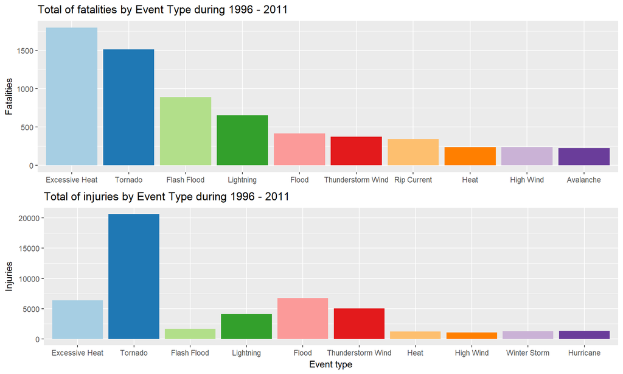

```r
# arrange both barplots
grid.arrange(gg_fatalities, gg_injuries, nrow = 2)
```

In one hand *Excessive Heat* is responsible of more deaths than any other type of weather event; on the other hand, *Tornado* lead to more injuires than any other weather event.

#### Across the U.S, which types of events have the greatest economic consequences?

#### Economic Effect

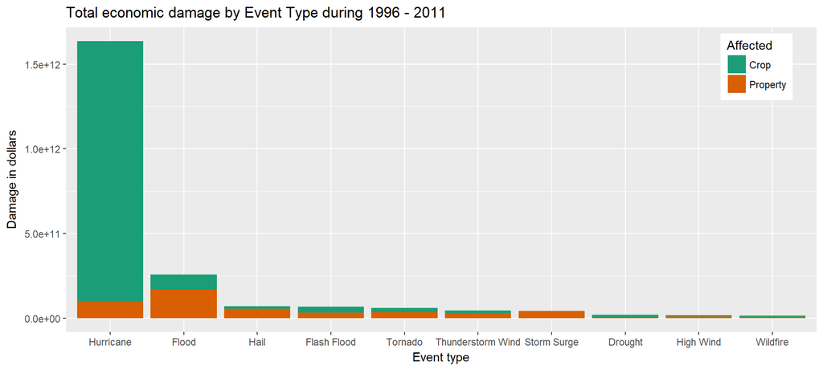

```r
# top 10, and ordering
top_10_damage <- storm_economic %>% count(evtype, wt = damage, sort = T) %>% head(10)
# subseting
storm_economic_ordered <- storm_economic %>%
  semi_join(top_10_damage, by = "evtype") %>%
  mutate(evtype = factor(evtype, levels = top_10_damage$evtype),
         type_damage = ifelse(type_damage == "cropdmg", "Crop", "Property"))
# plotting
storm_economic_ordered %>%
  ggplot(aes(evtype, damage, fill = type_damage)) +
  geom_bar(stat = "identity", position = "stack") +
  scale_fill_brewer(palette = "Dark2") +
  labs(x = "Event type", y = "Damage in dollars", fill = "Affected") +
  ggtitle("Total economic damage by Event Type during 1996 - 2011") +
  theme(legend.position = c(.92, .87))
```

Globally, *hurricanes* is the most harmful weather event in terms of economic damage, specially to crops; however, *floods* produced more damage to properties than any other weather event.

```
##  setting  value
##  version  R version 3.4.3 (2017-11-30)
##  system   x86_64, mingw32
##  ui       RTerm
##  language (EN)
##  collate  Spanish_Mexico.1252
##  tz       America/Mexico_City
##  date     2018-01-08
```

```
## Packages -----------------------------------------------------------------
```

[output not shown]